# ca_disturbance

2022-10-05

```r
rm(list=ls())
source("R/solar_model.R")
source("examples_vignettes/R/testing_integration.R")
source("tests/reference_leaf_updated.R")

library(tidyverse)
```

```r
library(ggplot2)
library(purrr)
library(deSolve)
library(lhs)
library(furrr)
```

Set some random parameters other than ca. We’ll just extract three for now.

```r
set.seed(203)
LHS <- randomLHS(3, 12)

params <- tibble(mean_temp = 20, temp_diff = qunif(LHS[,1], min = 5, max = 20), latitude = qunif(LHS[,2], min = 0, max = 60), VP = qunif(LHS[,3], 0.5, 2),
                   vcmax = qunif(LHS[,4], 30, 100), p_50 = qunif(LHS[,5], min = 1, max = 10), huber_value = qunif(LHS[,6], min = 0.000157/2, max =  0.000157*2),
                   day = qunif(LHS[,7], min = 0, 180), h = qunif(LHS[,8], min = 5, max = 80), E = qunif(LHS[,9], min = 0, max = 1), psi_soil = qunif(LHS[,10], 0, 3), c = qunif(LHS[,12], 1, 10))
```

Expand the params out for 3 chosen ca values, (post-industrial, near-term forecast, long-term forecast), and also some calculated traits. Then expand_grid by focal points required, and then calculate timeslices throughout day corresponding to number of focal points, calculate solar angle from these time slices and and latitude, get PAR, and then also calculate temp throughout the day in order to get VPD.

```r
params %>%
    mutate(param_set = seq(1:n())) %>%
  expand_grid(ca = seq(38, 50, 6)) %>%
   pmap(expand_input_data) %>%
  bind_rows() %>%
  expand_grid(focal_points = c(1, 50)) %>%
  mutate(instant_through_day_hr = pmap(., create_mult_point)) %>%
  unnest(instant_through_day_hr) %>%
  mutate(instant_through_day_dec = instant_through_day_hr/24,
         dec_day_time = day_floor+ instant_through_day_dec) %>%
  mutate(solar_angle = solar_angle(dec_day_time, latitude),
         PAR = PAR_given_solar_angle(solar_angle)) %>%
  rowwise() %>%
  mutate(temp = calc_temp(instant_through_day_hr, day_length, mean_temp, temp_diff, sun_rise, sun_down)) %>%
  mutate(VPD_hr = max(0.05, calc_vpsat(temp) - VP)) -> expanded_input_data
```

Create leaves corresponding to env values and trait values for each timeslice throughout the day. Individual leaves are requried for each time slice. Then, use leaf_states_from_leaf to optimise psi_stem, then extract profit, transpiraiton and other required values.

```r
expanded_input_data %>%
  ungroup() %>%
  mutate(leaf = pmap(., make_leaf)) %>%
  mutate(leaf_states_rate = map(leaf, leaf_states_rates_from_leaf)) %>%
  unnest(leaf_states_rate) %>%
  nest(outputs = c(leaf, instant_through_day_hr, instant_through_day_dec, dec_day_time, solar_angle, PAR, temp, VPD_hr, profit, transpiration, psi_stem, g_c)) -> expanded_output
```

```r
params
```

```
## # A tibble: 3 × 12
##   mean_temp temp_…¹ latit…²    VP vcmax  p_50 huber…³    day     h     E psi_s…⁴
##       <dbl>   <dbl>   <dbl> <dbl> <dbl> <dbl>   <dbl>  <dbl> <dbl> <dbl>   <dbl>
## 1        20    9.38    14.3 1.93   35.1  8.53 2.95e-4 109.    11.2 0.124   1.46
## 2        20   16.8     48.7 0.594  66.6  6.51 1.14e-4   1.88  79.3 0.407   2.62
## 3        20   10.4     30.2 1.14   97.8  1.98 1.87e-4 148.    39.3 0.968   0.566
## # … with 1 more variable: c <dbl>, and abbreviated variable names ¹temp_diff,
## #   ²latitude, ³huber_value, ⁴psi_soil
## # ℹ Use `colnames()` to see all variable names
```

Let’s make some plots. The first plot is the profit throughout the day for each of the three parameter sets experiencing three different levels of ca. The second is for transpiraiton.

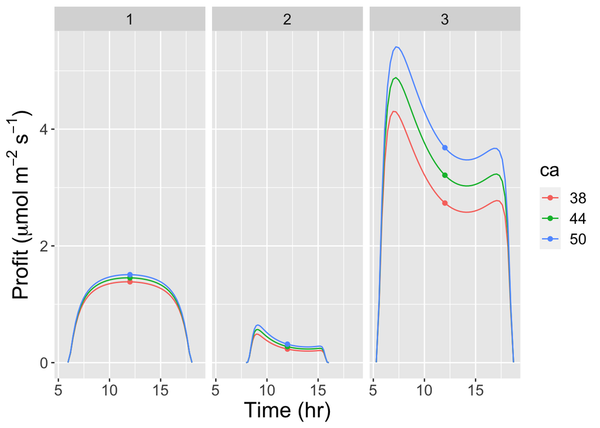

```r
expanded_output %>%
  filter(focal_points == 50) %>%
  unnest(outputs) %>%
  mutate(ca = as_factor(ca)) %>%
  ggplot() +
  geom_line(aes(x = instant_through_day_hr, y = profit, col = ca, group = ca)) +
  geom_point(data = expanded_output %>%
    filter(focal_points == 1) %>% unnest(outputs) %>%
  mutate(ca = as_factor(ca)), aes(x = instant_through_day_hr, y = profit, col = ca, group = ca)) +
  facet_wrap(~param_set) +
  theme(
  text = element_text(size=16),
  axis.title = element_text(size=18)
  ) +
  ylab(expression(paste("Profit (",mu,"mol ", m^{-2}~s^{-1},")"))) +
  xlab("Time (hr)")
```

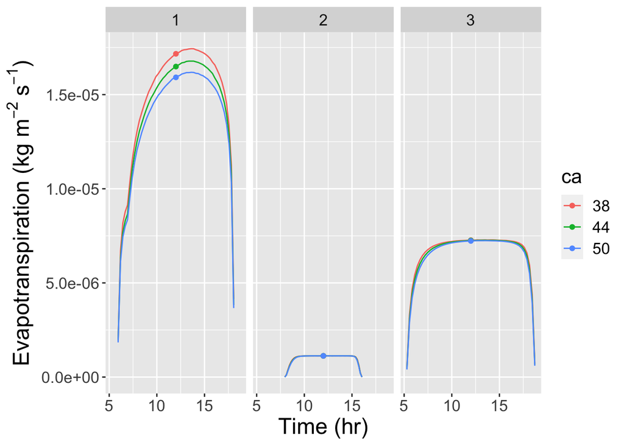

```r
expanded_output %>%
  filter(focal_points == 50) %>%
  unnest(outputs) %>%
  mutate(ca = as_factor(ca))%>%
  ggplot() +
  geom_line(aes(x = instant_through_day_hr, y = transpiration, col = ca, group = ca)) +
  geom_point(data = expanded_output %>%
    filter(focal_points == 1) %>% unnest(outputs)%>%
  mutate(ca = as_factor(ca)), aes(x = instant_through_day_hr, y = transpiration, col = ca, group = ca)) +
  facet_wrap(~param_set) +
  theme(
  text = element_text(size=16),
  axis.title = element_text(size=18)
  ) +
  ylab(expression(paste("Evapotranspiration (kg ", m^{-2}~s^{-1},")"))) +
  xlab("Time (hr)")
```

```r
expanded_output%>%
  filter(focal_points == 1) %>%
  unnest(outputs) %>%
  mutate(profit_curve = map2(.x = leaf, .y = psi_crit, ~profit_curves_from_leaf(.x, .y))) %>%
  unnest(profit_curve) -> profit_curves
```

Increasing ca causes profit to increase while transpiration decreases. This is because the cost curve does not change (other than a small scaling increase associated with changing lambda). By comparison, the benefit curve increases more rapidly as ca increases, causing the optimum psi stem to move leftwards (i.e. less negetative stem water pressure). As such, for a given optimum assimilation, less transpiration is required.

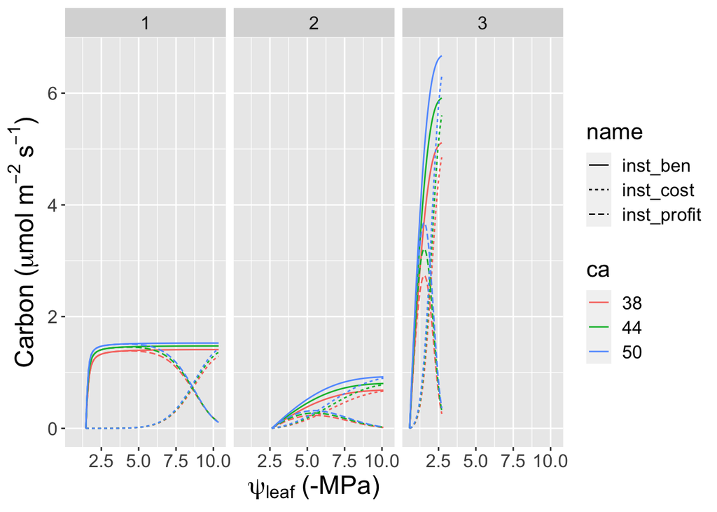

```r
profit_curves %>%
  mutate(ca = as_factor(ca))%>%
  pivot_longer(cols = c(inst_profit, inst_cost, inst_ben)) %>%
  ggplot() +
  geom_line(aes(x = inst_psi_stem, y = value, linetype = name, group = interaction(name, ca), colour = ca)) +
  facet_wrap(~param_set) +
  ylab(expression(paste("Carbon (",mu,"mol ", m^{-2}~s^{-1},")"))) +
  xlab(expression(paste(psi[leaf]," (-MPa)"))) +
  labs(main = "Midday profit curves") +
  theme(
  text = element_text(size=16),
  axis.title = element_text(size=18)
  )
```